# new AD model

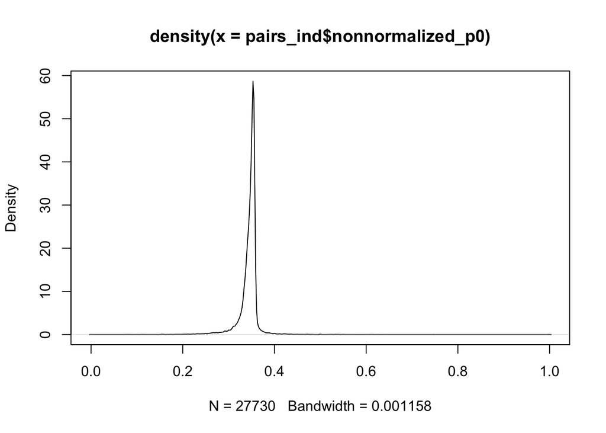

```r
plot(density(pairs_ind$nonnormalized_p0))
```

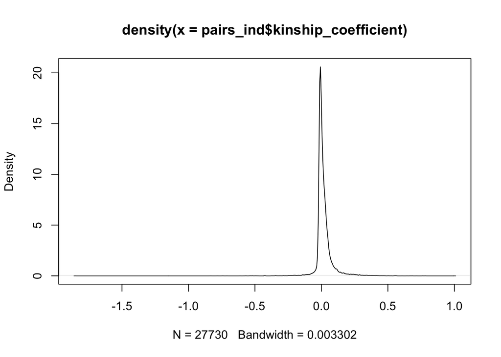

```r
plot(density(pairs_ind$kinship_coefficient))
```

**Remark:**

### Separated tomb

#### Binary separated (with categorical bones)

```r
binary_separate_cat <- readRDS(here::here("unofficial work/models save/binary_separate_cat.rds"))

summary(binary_separate_cat)
```

```
##  Family: bernoulli
##   Links: mu = logit
## Formula: related_binary ~ sex_pair + age_pair + bone_quality + same_tomb + (1 | mm(individual1_id, individual2_id)) + (1 | mm(tomb1, tomb2))
##    Data: pairs_ind (Number of observations: 13690)
##   Draws: 4 chains, each with iter = 2000; warmup = 1000; thin = 1;
##          total post-warmup draws = 4000
##
## Multilevel Hyperparameters:
## ~mmindividual1_idindividual2_id (Number of levels: 176)
##               Estimate Est.Error l-95% CI u-95% CI Rhat Bulk_ESS Tail_ESS
## sd(Intercept)     2.31      0.28     1.79     2.91 1.00     1416     2274
##
## ~mmtomb1tomb2 (Number of levels: 8)
##               Estimate Est.Error l-95% CI u-95% CI Rhat Bulk_ESS Tail_ESS
## sd(Intercept)     1.03      0.58     0.12     2.40 1.00      897      931
##
## Regression Coefficients:
##                      Estimate Est.Error l-95% CI u-95% CI Rhat Bulk_ESS
## Intercept               -7.85      0.82    -9.52    -6.23 1.00     1210
## sex_pairXXMXY            0.90      0.42     0.09     1.73 1.00     2067
## sex_pairXYMXY            1.92      0.56     0.86     3.07 1.00     1456
## age_pairbothsubadult     1.52      0.54     0.47     2.58 1.00     1272
## age_pairmixed            0.58      0.32    -0.05     1.20 1.00     1540
## bone_qualityhighMlow    -0.31      0.36    -1.03     0.42 1.00     1173
## bone_qualitylowMlow      0.37      0.65    -0.91     1.67 1.00     1090
## same_tombTRUE            2.24      0.22     1.80     2.67 1.00     4911
##                      Tail_ESS
## Intercept                1587
## sex_pairXXMXY            2251
## sex_pairXYMXY            2006
## age_pairbothsubadult     2237
## age_pairmixed            2478
## bone_qualityhighMlow     1991
## bone_qualitylowMlow      2013
## same_tombTRUE            2248
##
## Draws were sampled using sampling(NUTS). For each parameter, Bulk_ESS
## and Tail_ESS are effective sample size measures, and Rhat is the potential
## scale reduction factor on split chains (at convergence, Rhat = 1).
```

#### Binary separated (with Overlapping SNPs instead of bones)

```r
binary_separate_ov <- readRDS(here::here("unofficial work/models save/binary_separate_ov.rds"))

summary(binary_separate_ov)
```

```
##  Family: bernoulli
##   Links: mu = logit
## Formula: related_binary ~ sex_pair + age_pair + overlap_nsnps + same_tomb + (1 | mm(individual1_id, individual2_id)) + (1 | mm(tomb1, tomb2))
##    Data: pairs_ind (Number of observations: 13690)
##   Draws: 4 chains, each with iter = 2000; warmup = 1000; thin = 1;
##          total post-warmup draws = 4000
##
## Multilevel Hyperparameters:
## ~mmindividual1_idindividual2_id (Number of levels: 176)
##               Estimate Est.Error l-95% CI u-95% CI Rhat Bulk_ESS Tail_ESS
## sd(Intercept)     1.76      1.26     0.14     4.11 3.40        4       11
##
## ~mmtomb1tomb2 (Number of levels: 8)
##               Estimate Est.Error l-95% CI u-95% CI Rhat Bulk_ESS Tail_ESS
## sd(Intercept)     2.29      1.82     0.39     5.04 4.48        4       11
##
## Regression Coefficients:
##                      Estimate Est.Error l-95% CI u-95% CI Rhat Bulk_ESS
## Intercept               -1.54      0.61    -2.31    -0.70 2.59        5
## sex_pairXXMXY            0.56      0.58    -0.42     1.04 3.32        4
## sex_pairXYMXY           -0.04      0.95    -1.15     1.05 3.47        4
## age_pairbothsubadult    -0.68      0.39    -1.07    -0.15 3.49        4
## age_pairmixed            0.54      1.07    -1.04     1.81 3.91        4
## overlap_nsnps            0.00      0.00    -0.00     0.00 2.92        5
## same_tombTRUE            0.16      1.29    -1.94     1.42 3.33        5
##                      Tail_ESS
## Intercept                  12
## sex_pairXXMXY              16
## sex_pairXYMXY              12
## age_pairbothsubadult       11
## age_pairmixed              11
## overlap_nsnps              11
## same_tombTRUE              17
##
## Draws were sampled using sampling(NUTS). For each parameter, Bulk_ESS
## and Tail_ESS are effective sample size measures, and Rhat is the potential
## scale reduction factor on split chains (at convergence, Rhat = 1).
```

#### Numeric separated (with categorical bones)

```r
numeric_separate_cat <- readRDS(here::here("unofficial work/models save/numeric_separate_cat.rds"))

summary(numeric_separate_cat)
```

```
##  Family: gaussian
##   Links: mu = identity
## Formula: kinship_coefficient ~ sex_pair + age_pair + bone_quality + same_tomb + (1 | mm(individual1_id, individual2_id)) + (1 | mm(tomb1, tomb2))
##    Data: pairs_ind (Number of observations: 13690)
##   Draws: 4 chains, each with iter = 2000; warmup = 1000; thin = 1;
##          total post-warmup draws = 4000
##
## Multilevel Hyperparameters:
## ~mmindividual1_idindividual2_id (Number of levels: 176)
##               Estimate Est.Error l-95% CI u-95% CI Rhat Bulk_ESS Tail_ESS
## sd(Intercept)     0.02      0.00     0.02     0.02 1.01      228      657
##
## ~mmtomb1tomb2 (Number of levels: 8)
##               Estimate Est.Error l-95% CI u-95% CI Rhat Bulk_ESS Tail_ESS
## sd(Intercept)     0.01      0.00     0.00     0.02 1.07       64      222
##
## Regression Coefficients:
##                      Estimate Est.Error l-95% CI u-95% CI Rhat Bulk_ESS
## Intercept               -0.01      0.00    -0.02     0.00 1.03      182
## sex_pairXXMXY            0.00      0.00     0.00     0.01 1.06      101
## sex_pairXYMXY            0.01      0.00     0.00     0.01 1.06      100
## age_pairbothsubadult     0.00      0.00    -0.00     0.01 1.01      162
## age_pairmixed            0.00      0.00    -0.00     0.00 1.01      161
## bone_qualityhighMlow     0.00      0.00    -0.00     0.00 1.03      160
## bone_qualitylowMlow      0.00      0.00    -0.00     0.01 1.03      161
## same_tombTRUE            0.01      0.00     0.00     0.01 1.00     3768
##                      Tail_ESS
## Intercept                 273
## sex_pairXXMXY             239
## sex_pairXYMXY             247
## age_pairbothsubadult      298
## age_pairmixed             312
## bone_qualityhighMlow      322
## bone_qualitylowMlow       331
## same_tombTRUE            3150
##
## Further Distributional Parameters:
##       Estimate Est.Error l-95% CI u-95% CI Rhat Bulk_ESS Tail_ESS
## sigma     0.01      0.00     0.01     0.01 1.00     2599     2537
##
## Draws were sampled using sampling(NUTS). For each parameter, Bulk_ESS
## and Tail_ESS are effective sample size measures, and Rhat is the potential
## scale reduction factor on split chains (at convergence, Rhat = 1).
```

#### Numeric separated (with Overlapping SNPs instead of bones)

```r
numeric_separate_ov <- readRDS(here::here("unofficial work/models save/numeric_separate_ov.rds"))

summary(numeric_separate_ov)
```

```
##  Family: gaussian
##   Links: mu = identity
## Formula: kinship_coefficient ~ sex_pair + age_pair + overlap_nsnps + same_tomb + (1 | mm(individual1_id, individual2_id)) + (1 | mm(tomb1, tomb2))
##    Data: pairs_ind (Number of observations: 13690)
##   Draws: 4 chains, each with iter = 2000; warmup = 1000; thin = 1;
##          total post-warmup draws = 4000
##
## Multilevel Hyperparameters:
## ~mmindividual1_idindividual2_id (Number of levels: 176)
##               Estimate Est.Error l-95% CI u-95% CI Rhat Bulk_ESS Tail_ESS
## sd(Intercept)     0.66      0.38     0.20     1.26 3.40        4       11
##
## ~mmtomb1tomb2 (Number of levels: 8)
##               Estimate Est.Error l-95% CI u-95% CI Rhat Bulk_ESS Tail_ESS
## sd(Intercept)     0.23      0.09     0.14     0.38 3.65        4       11
##
## Regression Coefficients:
##                      Estimate Est.Error l-95% CI u-95% CI Rhat Bulk_ESS
## Intercept               -0.94      0.29    -1.22    -0.44 2.57        5
## sex_pairXXMXY            0.56      0.58    -0.42     1.04 4.21        4
## sex_pairXYMXY           -0.04      0.95    -1.15     1.06 3.08        5
## age_pairbothsubadult    -0.68      0.39    -1.07    -0.15 3.00        5
## age_pairmixed            0.53      1.07    -1.03     1.81 3.29        4
## overlap_nsnps           -0.00      0.00    -0.00     0.00 2.01        5
## same_tombTRUE            0.16      1.28    -1.92     1.41 3.34        4
##                      Tail_ESS
## Intercept                  26
## sex_pairXXMXY              11
## sex_pairXYMXY              20
## age_pairbothsubadult       13
## age_pairmixed              11
## overlap_nsnps              28
## same_tombTRUE              11
##
## Further Distributional Parameters:
##       Estimate Est.Error l-95% CI u-95% CI Rhat Bulk_ESS Tail_ESS
## sigma     1.66      0.72     0.53     2.79 2.84        5       11
##
## Draws were sampled using sampling(NUTS). For each parameter, Bulk_ESS
## and Tail_ESS are effective sample size measures, and Rhat is the potential
## scale reduction factor on split chains (at convergence, Rhat = 1).
```

### Compare models

#### Model health

```r
# 1. Put your models in a list (Make sure these objects exist in your environment)
model_list <- list(
  "binary_separate_cat" = binary_separate_cat,
  "binary_separate_ov"  = binary_separate_ov,
  "numeric_separate_cat" = numeric_separate_cat, # Be careful if this one is broken/missing
  "numeric_separate_ov"  = numeric_separate_ov   # Be careful if this one is broken/missing
)

# 2. Corrected Function
get_model_stats <- function(model, name) {

  # A. Model Health
  # Use nuts_params from brms to get divergences
  nuts <- tryCatch(nuts_params(model), error = function(e) NULL)
  if(!is.null(nuts)) {
    divs <- sum(subset(nuts, Parameter == "divergent__")$Value)
  } else {
    divs <- NA # Handle cases where model crashed
  }

  # FIX FOR RHAT ERROR:
  # We extract Rhats directly from the rhat() function in brms namespace
  # If that fails, we return NA
  r_values <- tryCatch(brms::rhat(model), error = function(e) NA)
  rhat_max <- max(r_values, na.rm = TRUE)

  # B. Model Fit (WAIC)
  waic_val <- tryCatch(waic(model)$estimates["waic", "Estimate"], error = function(e) NA)

  # C. Key Biological Coefficients
  # We use fixef() which is standard for brms
  fix <- fixef(model)

  # Extract Male-Male Effect (Adjust string "XYMXY" if your summary shows differently)
  # using grep to find the row that matches "XYMXY" even if the name varies slightly
  mm_row <- grep("XYMXY", rownames(fix))
  beta_MM <- if(length(mm_row) > 0) fix[mm_row, "Estimate"] else NA

  # Extract Subadult Effect
  sub_row <- grep("subadult", rownames(fix))
  beta_Subadult <- if(length(sub_row) > 0) fix[sub_row, "Estimate"] else NA

  # D. Random Effect Variances
  # Safely extract variances
  vars <- VarCorr(model)

  # Extract Individual Variance (mm function)
  # Note: The name is usually 'mmindividual1_idindividual2_id' but might vary
  sd_ind <- NA
  if("mmindividual1_idindividual2_id" %in% names(vars)) {
    sd_ind <- vars$mmindividual1_idindividual2_id$sd[1]
  }

  # Extract Tomb Variance
  sd_tomb <- NA
  if("mmtomb1tomb2" %in% names(vars)) {
    sd_tomb <- vars$mmtomb1tomb2$sd[1]
  }

  return(data.frame(
    Model = name,
    Divergences = divs,
    Max_Rhat = round(rhat_max, 3),
    WAIC = round(waic_val, 1),
    Est_MaleMale = round(beta_MM, 2),
    Est_Subadult = round(beta_Subadult, 2),
    SD_Ind = round(sd_ind, 2),
    SD_Tomb = round(sd_tomb, 2)
  ))
}

# 3. Run and Bind
comparison_table <- bind_rows(lapply(names(model_list), function(x) get_model_stats(model_list[[x]], x)))
# 4. View
comparison_table
```

```
##                  Model Divergences Max_Rhat     WAIC Est_MaleMale Est_Subadult
## 1  binary_separate_cat          11    1.005   1175.5         1.92         1.52
## 2   binary_separate_ov           0    4.534  37291.8        -0.04        -0.68
## 3 numeric_separate_cat          30    1.074 -79681.8         0.01         0.00
## 4  numeric_separate_ov         763    4.514 213268.8        -0.04        -0.68
##   SD_Ind SD_Tomb
## 1   2.31    1.03
## 2   1.76    2.29
## 3   0.02    0.01
## 4   0.66    0.23
```

**Comment:**

**Source:** - https://mc-stan.org/learn-stan/diagnostics-warnings.html - https://easystats.github.io/bayestestR/reference/effective_sample.html

**Improve:** - Rerun with higher adapt_delta (0.999) and more iteration

### Improved version

#### Separated tomb

```r
imp_binary_separate_cat <- readRDS(here::here("unofficial work/models save/imp_binary_separate_cat.rds"))
summary(imp_binary_separate_cat)
```

```
##  Family: bernoulli
##   Links: mu = logit
## Formula: related_binary ~ sex_pair + age_pair + bone_quality + same_tomb + (1 | mm(individual1_id, individual2_id)) + (1 | mm(tomb1, tomb2))
##    Data: pairs_ind (Number of observations: 13690)
##   Draws: 4 chains, each with iter = 6000; warmup = 3000; thin = 1;
##          total post-warmup draws = 12000
##
## Multilevel Hyperparameters:
## ~mmindividual1_idindividual2_id (Number of levels: 176)
##               Estimate Est.Error l-95% CI u-95% CI Rhat Bulk_ESS Tail_ESS
## sd(Intercept)     2.31      0.28     1.80     2.91 1.00     4025     6763
##
## ~mmtomb1tomb2 (Number of levels: 8)
##               Estimate Est.Error l-95% CI u-95% CI Rhat Bulk_ESS Tail_ESS
## sd(Intercept)     1.07      0.66     0.13     2.78 1.00     2311     2237
##
## Regression Coefficients:
##                      Estimate Est.Error l-95% CI u-95% CI Rhat Bulk_ESS
## Intercept               -7.84      0.83    -9.46    -6.19 1.00     4873
## sex_pairXXMXY            0.91      0.42     0.11     1.77 1.00     8525
## sex_pairXYMXY            1.93      0.56     0.86     3.08 1.00     6198
## age_pairbothsubadult     1.52      0.54     0.45     2.55 1.00     5623
## age_pairmixed            0.57      0.32    -0.05     1.22 1.00     6746
## bone_qualityhighMlow    -0.30      0.36    -1.00     0.41 1.00     4872
## bone_qualitylowMlow      0.38      0.64    -0.90     1.63 1.00     4277
## same_tombTRUE            2.24      0.21     1.82     2.66 1.00    19032
##                      Tail_ESS
## Intercept                6074
## sex_pairXXMXY            9132
## sex_pairXYMXY            7903
## age_pairbothsubadult     7351
## age_pairmixed            9083
## bone_qualityhighMlow     6616
## bone_qualitylowMlow      5966
## same_tombTRUE            8733
##
## Draws were sampled using sampling(NUTS). For each parameter, Bulk_ESS
## and Tail_ESS are effective sample size measures, and Rhat is the potential
## scale reduction factor on split chains (at convergence, Rhat = 1).
```

#### Group tomb

```r
imp_binary_group_cat <- readRDS(here::here("unofficial work/models save/imp_binary_group_cat.rds"))
summary(imp_binary_group_cat)
```

```
##  Family: bernoulli
##   Links: mu = logit
## Formula: related_binary ~ sex_pair + age_pair + bone_quality + same_tomb + (1 | mm(individual1_id, individual2_id)) + (1 | mm(tomb1, tomb2))
##    Data: pairs_group (Number of observations: 13690)
##   Draws: 4 chains, each with iter = 6000; warmup = 3000; thin = 1;
##          total post-warmup draws = 12000
##
## Multilevel Hyperparameters:
## ~mmindividual1_idindividual2_id (Number of levels: 176)
##               Estimate Est.Error l-95% CI u-95% CI Rhat Bulk_ESS Tail_ESS
## sd(Intercept)     2.27      0.28     1.76     2.85 1.00     4262     6902
##
## ~mmtomb1tomb2 (Number of levels: 6)
##               Estimate Est.Error l-95% CI u-95% CI Rhat Bulk_ESS Tail_ESS
## sd(Intercept)     1.71      1.09     0.34     4.50 1.00     2964     3708
##
## Regression Coefficients:
##                      Estimate Est.Error l-95% CI u-95% CI Rhat Bulk_ESS
## Intercept               -8.00      1.16   -10.14    -5.56 1.00     4832
## sex_pairXXMXY            0.87      0.42     0.08     1.71 1.00     8445
## sex_pairXYMXY            1.93      0.55     0.87     3.04 1.00     6364
## age_pairbothsubadult     1.43      0.54     0.37     2.50 1.00     5766
## age_pairmixed            0.56      0.32    -0.05     1.21 1.00     6467
## bone_qualityhighMlow    -0.35      0.34    -1.01     0.32 1.00     5855
## bone_qualitylowMlow      0.42      0.61    -0.77     1.61 1.00     5034
## same_tombTRUE            2.57      0.25     2.10     3.08 1.00    20061
##                      Tail_ESS
## Intercept                5243
## sex_pairXXMXY            9076
## sex_pairXYMXY            8021
## age_pairbothsubadult     7217
## age_pairmixed            8138
## bone_qualityhighMlow     7692
## bone_qualitylowMlow      7172
## same_tombTRUE            9117
##
## Draws were sampled using sampling(NUTS). For each parameter, Bulk_ESS
## and Tail_ESS are effective sample size measures, and Rhat is the potential
## scale reduction factor on split chains (at convergence, Rhat = 1).
```

**Comment:**

- So much better outcome
- No divergence, Rhat = 1, all large ESS
- No drastical difference compare to the previous model with divergence, indicate that the 11 divergences were negligible
- The “Same Tomb” effect got stronger
  - If the grouping was random, the effect would likely be weaker
  - But it got stronger => the relatedness in grouped tomb is more confirmed

### Compare between 15k threshold and original threhold

#### Separated tomb

```r
imp_binary_separate_cat <- readRDS(here::here("unofficial work/models save/imp_binary_separate_cat.rds"))
all_binary_separate_cat <- readRDS(here::here("unofficial work/models save/all_binary_separate_cat.rds"))
ogthreshold_vs_15k <- readRDS(here::here("unofficial work/models save/ogthreshold_vs_15k.rds"))


summary(imp_binary_separate_cat)
```

```
##  Family: bernoulli
##   Links: mu = logit
## Formula: related_binary ~ sex_pair + age_pair + bone_quality + same_tomb + (1 | mm(individual1_id, individual2_id)) + (1 | mm(tomb1, tomb2))
##    Data: pairs_ind (Number of observations: 13690)
##   Draws: 4 chains, each with iter = 6000; warmup = 3000; thin = 1;
##          total post-warmup draws = 12000
##
## Multilevel Hyperparameters:
## ~mmindividual1_idindividual2_id (Number of levels: 176)
##               Estimate Est.Error l-95% CI u-95% CI Rhat Bulk_ESS Tail_ESS
## sd(Intercept)     2.31      0.28     1.80     2.91 1.00     4025     6763
##
## ~mmtomb1tomb2 (Number of levels: 8)
##               Estimate Est.Error l-95% CI u-95% CI Rhat Bulk_ESS Tail_ESS
## sd(Intercept)     1.07      0.66     0.13     2.78 1.00     2311     2237
##
## Regression Coefficients:
##                      Estimate Est.Error l-95% CI u-95% CI Rhat Bulk_ESS
## Intercept               -7.84      0.83    -9.46    -6.19 1.00     4873
## sex_pairXXMXY            0.91      0.42     0.11     1.77 1.00     8525
## sex_pairXYMXY            1.93      0.56     0.86     3.08 1.00     6198
## age_pairbothsubadult     1.52      0.54     0.45     2.55 1.00     5623
## age_pairmixed            0.57      0.32    -0.05     1.22 1.00     6746
## bone_qualityhighMlow    -0.30      0.36    -1.00     0.41 1.00     4872
## bone_qualitylowMlow      0.38      0.64    -0.90     1.63 1.00     4277
## same_tombTRUE            2.24      0.21     1.82     2.66 1.00    19032
##                      Tail_ESS
## Intercept                6074
## sex_pairXXMXY            9132
## sex_pairXYMXY            7903
## age_pairbothsubadult     7351
## age_pairmixed            9083
## bone_qualityhighMlow     6616
## bone_qualitylowMlow      5966
## same_tombTRUE            8733
##
## Draws were sampled using sampling(NUTS). For each parameter, Bulk_ESS
## and Tail_ESS are effective sample size measures, and Rhat is the potential
## scale reduction factor on split chains (at convergence, Rhat = 1).
```

```r
summary(all_binary_separate_cat)
```

```
##  Family: bernoulli
##   Links: mu = logit
## Formula: related_binary ~ sex_pair + age_pair + bone_quality + same_tomb + (1 | mm(individual1_id, individual2_id)) + (1 | mm(tomb1, tomb2))
##    Data: pairs_ind_all (Number of observations: 13794)
##   Draws: 4 chains, each with iter = 6000; warmup = 3000; thin = 1;
##          total post-warmup draws = 12000
##
## Multilevel Hyperparameters:
## ~mmindividual1_idindividual2_id (Number of levels: 212)
##               Estimate Est.Error l-95% CI u-95% CI Rhat Bulk_ESS Tail_ESS
## sd(Intercept)     7.34      0.71     6.07     8.86 1.00     2545     5270
##
## ~mmtomb1tomb2 (Number of levels: 8)
##               Estimate Est.Error l-95% CI u-95% CI Rhat Bulk_ESS Tail_ESS
## sd(Intercept)     0.89      0.74     0.04     2.74 1.00     1301     3018
##
## Regression Coefficients:
##                      Estimate Est.Error l-95% CI u-95% CI Rhat Bulk_ESS
## Intercept               -6.96      1.29    -9.49    -4.46 1.00     1271
## sex_pairXXMXY            0.73      0.64    -0.53     1.98 1.00     1299
## sex_pairXYMXY            1.39      1.16    -0.94     3.64 1.01     1111
## age_pairbothsubadult     1.64      1.27    -0.83     4.12 1.00     1009
## age_pairmixed            0.65      0.65    -0.63     1.95 1.00     1060
## bone_qualityhighMlow     0.52      0.65    -0.75     1.81 1.00     1227
## bone_qualitylowMlow      1.41      1.26    -1.10     3.92 1.00     1190
## same_tombTRUE            2.38      0.20     1.99     2.78 1.00    13360
##                      Tail_ESS
## Intercept                3122
## sex_pairXXMXY            2778
## sex_pairXYMXY            2258
## age_pairbothsubadult     2159
## age_pairmixed            2333
## bone_qualityhighMlow     1982
## bone_qualitylowMlow      1980
## same_tombTRUE            9111
##
## Draws were sampled using sampling(NUTS). For each parameter, Bulk_ESS
## and Tail_ESS are effective sample size measures, and Rhat is the potential
## scale reduction factor on split chains (at convergence, Rhat = 1).
```

```r
ogthreshold_vs_15k
```

|  | Model with 15k threshold | Model with original threshold |
| --- | --- | --- |
| b_Intercept | -7.841 | -6.966 |
| b_sex_pairXXMXY | 0.899 | 0.725 |
| b_sex_pairXYMXY | 1.921 | 1.382 |
| b_age_pairbothsubadult | 1.512 | 1.641 |
| b_age_pairmixed | 0.572 | 0.651 |
| b_bone_qualityhighMlow | -0.302 | 0.517 |
| b_bone_qualitylowMlow | 0.381 | 1.406 |
| b_same_tombTRUE | 2.237 | 2.379 |
| sd_mmindividual1_idindividual2_id__Intercept | 2.297 | 7.292 |
| sd_mmtomb1tomb2__Intercept | 0.949 | 0.712 |
| Num.Obs. | 13690 | 13794 |
| R2 | 0.097 | 0.385 |
| R2 Marg. | 0.014 | 0.078 |
| ICC | 0.8 | 0.9 |
| ELPD | -587.7 | -693.6 |
| ELPD s.e. | 44.0 | 46.4 |
| LOOIC | 1175.4 | 1387.2 |
| LOOIC s.e. | 88.1 | 92.8 |
| WAIC | 1173.3 | 1349.5 |
| RMSE | 0.09 | 0.09 |

**Comment:**

- Model with original threshold is not reliable: high individual variance, most of the parameters are insignificant, worse diagnostics than the 15k threshold
- Comparison table point out that:
  - Original threshold explains more variance (higher $R^2$)
  - 15k predicts new data better (ELPD, LOOIC, WAIC)
  - $\Rightarrow$ Indicates using original threshold is more complex and overfitting.
- However most of the parameters give the same qualitative results (except b_bone_qualityhighMlow)

### Compare between with and without bone quality

Logic of this sensitivity analysis:

Because “Tomb” $\rightarrow$ “Preservation” $\rightarrow$ “Observed kinship”, therefore we added bone_quality to the model before to control for the path between “Tomb” and “Kinship”. So that the relationship between Tomb and Kinship not just an artifact of preservation.

But does this “preservation bias” really exist (and need to be controlled by the bone quality)? Or was it already taken care of from when we filter 15k threshold (only qualified sample)?

$\Rightarrow$ Sensitivity analysis:

- Bias: If when we remove bone_quality, the “Same Tomb” coefficient shifts wildly because it suddenly has to absorb the preservation bias. Then we still need to add bone_quality in the model.
- No bias: When we remove bone_quality, the same_tomb coefficient stays stable. Then we can just delete bone_quality (which makes the model simpler and easier to interpret).

```r
imp_binary_separate_cat <- readRDS(here::here("unofficial work/models save/imp_binary_separate_cat.rds"))
imp_binary_separate_nobone <- readRDS(here::here("unofficial work/models save/imp_binary_separate_nobone.rds"))
bone_vs_nobone <- readRDS(here::here("unofficial work/models save/bone_vs_nobone.rds"))


summary(imp_binary_separate_cat)
```

```
##  Family: bernoulli
##   Links: mu = logit
## Formula: related_binary ~ sex_pair + age_pair + bone_quality + same_tomb + (1 | mm(individual1_id, individual2_id)) + (1 | mm(tomb1, tomb2))
##    Data: pairs_ind (Number of observations: 13690)
##   Draws: 4 chains, each with iter = 6000; warmup = 3000; thin = 1;
##          total post-warmup draws = 12000
##
## Multilevel Hyperparameters:
## ~mmindividual1_idindividual2_id (Number of levels: 176)
##               Estimate Est.Error l-95% CI u-95% CI Rhat Bulk_ESS Tail_ESS
## sd(Intercept)     2.31      0.28     1.80     2.91 1.00     4025     6763
##
## ~mmtomb1tomb2 (Number of levels: 8)
##               Estimate Est.Error l-95% CI u-95% CI Rhat Bulk_ESS Tail_ESS
## sd(Intercept)     1.07      0.66     0.13     2.78 1.00     2311     2237
##
## Regression Coefficients:
##                      Estimate Est.Error l-95% CI u-95% CI Rhat Bulk_ESS
## Intercept               -7.84      0.83    -9.46    -6.19 1.00     4873
## sex_pairXXMXY            0.91      0.42     0.11     1.77 1.00     8525
## sex_pairXYMXY            1.93      0.56     0.86     3.08 1.00     6198
## age_pairbothsubadult     1.52      0.54     0.45     2.55 1.00     5623
## age_pairmixed            0.57      0.32    -0.05     1.22 1.00     6746
## bone_qualityhighMlow    -0.30      0.36    -1.00     0.41 1.00     4872
## bone_qualitylowMlow      0.38      0.64    -0.90     1.63 1.00     4277
## same_tombTRUE            2.24      0.21     1.82     2.66 1.00    19032
##                      Tail_ESS
## Intercept                6074
## sex_pairXXMXY            9132
## sex_pairXYMXY            7903
## age_pairbothsubadult     7351
## age_pairmixed            9083
## bone_qualityhighMlow     6616
## bone_qualitylowMlow      5966
## same_tombTRUE            8733
##
## Draws were sampled using sampling(NUTS). For each parameter, Bulk_ESS
## and Tail_ESS are effective sample size measures, and Rhat is the potential
## scale reduction factor on split chains (at convergence, Rhat = 1).
```

```r
summary(imp_binary_separate_nobone)
```

```
##  Family: bernoulli
##   Links: mu = logit
## Formula: related_binary ~ sex_pair + age_pair + same_tomb + (1 | mm(individual1_id, individual2_id)) + (1 | mm(tomb1, tomb2))
##    Data: pairs_ind (Number of observations: 13690)
##   Draws: 4 chains, each with iter = 6000; warmup = 3000; thin = 1;
##          total post-warmup draws = 12000
##
## Multilevel Hyperparameters:
## ~mmindividual1_idindividual2_id (Number of levels: 176)
##               Estimate Est.Error l-95% CI u-95% CI Rhat Bulk_ESS Tail_ESS
## sd(Intercept)     2.29      0.28     1.79     2.88 1.00     4300     7277
##
## ~mmtomb1tomb2 (Number of levels: 8)
##               Estimate Est.Error l-95% CI u-95% CI Rhat Bulk_ESS Tail_ESS
## sd(Intercept)     1.16      0.65     0.30     2.80 1.00     3341     3621
##
## Regression Coefficients:
##                      Estimate Est.Error l-95% CI u-95% CI Rhat Bulk_ESS
## Intercept               -7.88      0.79    -9.49    -6.35 1.00     5873
## sex_pairXXMXY            0.92      0.42     0.11     1.79 1.00     9421
## sex_pairXYMXY            1.94      0.57     0.86     3.10 1.00     6686
## age_pairbothsubadult     1.51      0.52     0.52     2.54 1.00     5578
## age_pairmixed            0.55      0.31    -0.05     1.15 1.00     6639
## same_tombTRUE            2.30      0.21     1.89     2.72 1.00    22386
##                      Tail_ESS
## Intercept                7163
## sex_pairXXMXY            9525
## sex_pairXYMXY            8273
## age_pairbothsubadult     7698
## age_pairmixed            8546
## same_tombTRUE            8181
##
## Draws were sampled using sampling(NUTS). For each parameter, Bulk_ESS
## and Tail_ESS are effective sample size measures, and Rhat is the potential
## scale reduction factor on split chains (at convergence, Rhat = 1).
```

```r
bone_vs_nobone
```

|  | Model with bone quality | Model without bone quality |
| --- | --- | --- |
| b_Intercept | -7.841 | -7.870 |
| b_sex_pairXXMXY | 0.899 | 0.902 |
| b_sex_pairXYMXY | 1.921 | 1.931 |
| b_age_pairbothsubadult | 1.512 | 1.509 |
| b_age_pairmixed | 0.572 | 0.543 |
| b_bone_qualityhighMlow | -0.302 |  |
| b_bone_qualitylowMlow | 0.381 |  |
| b_same_tombTRUE | 2.237 | 2.299 |
| sd_mmindividual1_idindividual2_id__Intercept | 2.297 | 2.283 |
| sd_mmtomb1tomb2__Intercept | 0.949 | 1.030 |
| Num.Obs. | 13690 | 13690 |
| R2 | 0.097 | 0.095 |
| R2 Marg. | 0.014 | 0.015 |
| ICC | 0.7 | 0.7 |
| ELPD | -587.7 | -588.4 |
| ELPD s.e. | 44.0 | 44.1 |
| LOOIC | 1175.4 | 1176.7 |
| LOOIC s.e. | 88.1 | 88.1 |
| WAIC | 1173.3 | 1174.5 |
| RMSE | 0.09 | 0.09 |

**Comment:** - The model stays stable - No bone model even gives better diagnostics $\Rightarrow$ mathematically cleaner - The compared metrics are nearly identical, no metric provides meaningful evidence that one model is better

$\Rightarrow$ Prefer the no bone model, since it’s simpler, easier to interpret, and mathematically cleaner without losing scientific accuracy.

### Add tomb variables

Additional variables:

- sample_success_min:
  - The effective information for the pair is given by the minimum of the 2 tomb sizes. Because the larger sample can not compensate for the lack of information on the smaller side.
  - Interpretation/Intuition: Pairs that has higher sample success are more likely to be related
- analysed_ind_min:
  - Interpretation/Intuition: Pairs that are evaluated in a higher analysed samples (richer context) are more likely to be related
  - This accounts for **contextual sampling depth**
  - Concern: Wouldn’t this cause multicollinearity with sample_success_min? Check: cor = 0.70 => pretty high. Support a sensitivity check with dropping sample_success_min
- length_of_use_absdiff: account for **temporal context**
  - Interpretation/Intuition:
    - If negative: tombs has smaller different length of use are more likely to be used to bury the related poeple (so like they have the same temporal context so they are more likely to be related).
    - If positive: not so intuitive

```r
imp_binary_separate_tombvar <- readRDS(here::here("unofficial work/models save/imp_binary_separate_tombvar.rds"))
summary(imp_binary_separate_tombvar)
```

```
##  Family: bernoulli
##   Links: mu = logit
## Formula: related_binary ~ sex_pair + age_pair + same_tomb + sample_success_min + analysed_ind_min + length_of_use_absdiff + (1 | mm(individual1_id, individual2_id)) + (1 | mm(tomb1, tomb2))
##    Data: pairs_ind (Number of observations: 13690)
##   Draws: 4 chains, each with iter = 6000; warmup = 3000; thin = 1;
##          total post-warmup draws = 12000
##
## Multilevel Hyperparameters:
## ~mmindividual1_idindividual2_id (Number of levels: 176)
##               Estimate Est.Error l-95% CI u-95% CI Rhat Bulk_ESS Tail_ESS
## sd(Intercept)     2.30      0.28     1.79     2.90 1.00     3932     6429
##
## ~mmtomb1tomb2 (Number of levels: 8)
##               Estimate Est.Error l-95% CI u-95% CI Rhat Bulk_ESS Tail_ESS
## sd(Intercept)     2.38      1.04     0.97     4.92 1.00     3941     5602
##
## Regression Coefficients:
##                       Estimate Est.Error l-95% CI u-95% CI Rhat Bulk_ESS
## Intercept                -4.42      1.79    -7.84    -0.70 1.00     5765
## sex_pairXXMXY             0.90      0.42     0.11     1.77 1.00     7195
## sex_pairXYMXY             1.92      0.57     0.85     3.08 1.00     5437
## age_pairbothsubadult      1.50      0.53     0.46     2.55 1.00     4542
## age_pairmixed             0.55      0.32    -0.07     1.18 1.00     5477
## same_tombTRUE             3.10      0.47     2.21     4.06 1.00     8176
## sample_success_min      -14.83      4.64   -24.31    -6.22 1.00     6793
## analysed_ind_min          0.06      0.02     0.03     0.10 1.00     8355
## length_of_use_absdiff     0.01      0.00     0.00     0.02 1.00     9436
##                       Tail_ESS
## Intercept                 6559
## sex_pairXXMXY             7461
## sex_pairXYMXY             6701
## age_pairbothsubadult      6649
## age_pairmixed             7817
## same_tombTRUE             8013
## sample_success_min        7930
## analysed_ind_min          8470
## length_of_use_absdiff     8843
##
## Draws were sampled using sampling(NUTS). For each parameter, Bulk_ESS
## and Tail_ESS are effective sample size measures, and Rhat is the potential
## scale reduction factor on split chains (at convergence, Rhat = 1).
```

**Comment:**

- The model converges unexpectedly
- The diagnostics are not as great as the normal model
- Most of the old parameters stay stable
- Parameter for sample_success_min is VERY NEGATIVE (=> do sensitivity analysis):
  - Interpretation: Higher success rate => Lower probability of relatedness
  - **How could this make sense:**
    - High success rate => analyse many random people from the tomb => higher unrelated pairs (since we have low related rate) => family members are diluted in large # random people
    - Low success rate => only few bones survive the poor preservation context => those who survive might be clustered in a specific protected spot => could be a spot that is preserved for family => higher probability of relatedness
  - Anyway this parameter is added to control this “diluted bias” more than to describe any reality
- length_of_use_absdiff has very weak effect (even not significant) => also test sensitivity analysis for this

#### Sensitivity analysis for tomb-level variables

- Keep variables if: model quality metrics get worse when dropping them
- Drop if: model quality metrics stay stable

```r
imp_binary_separate_tombvar_nosamplesuccess <- readRDS(here::here("unofficial work/models save/imp_binary_separate_tombvar_nosamplesuccess.rds"))
summary(imp_binary_separate_tombvar_nosamplesuccess)
```

```
##  Family: bernoulli
##   Links: mu = logit
## Formula: related_binary ~ sex_pair + age_pair + same_tomb + analysed_ind_min + length_of_use_absdiff + (1 | mm(individual1_id, individual2_id)) + (1 | mm(tomb1, tomb2))
##    Data: pairs_ind (Number of observations: 13690)
##   Draws: 4 chains, each with iter = 6000; warmup = 3000; thin = 1;
##          total post-warmup draws = 12000
##
## Multilevel Hyperparameters:
## ~mmindividual1_idindividual2_id (Number of levels: 176)
##               Estimate Est.Error l-95% CI u-95% CI Rhat Bulk_ESS Tail_ESS
## sd(Intercept)     2.30      0.28     1.78     2.88 1.00     4083     6865
##
## ~mmtomb1tomb2 (Number of levels: 8)
##               Estimate Est.Error l-95% CI u-95% CI Rhat Bulk_ESS Tail_ESS
## sd(Intercept)     2.44      1.10     0.93     5.15 1.00     4784     6837
##
## Regression Coefficients:
##                       Estimate Est.Error l-95% CI u-95% CI Rhat Bulk_ESS
## Intercept                -8.79      1.20   -11.18    -6.39 1.00     8020
## sex_pairXXMXY             0.92      0.42     0.12     1.78 1.00    11859
## sex_pairXYMXY             1.96      0.57     0.88     3.10 1.00     8911
## age_pairbothsubadult      1.51      0.52     0.49     2.54 1.00     7486
## age_pairmixed             0.56      0.31    -0.06     1.18 1.00     8583
## same_tombTRUE             2.21      0.35     1.55     2.92 1.00    17625
## analysed_ind_min          0.03      0.01     0.00     0.06 1.00    12622
## length_of_use_absdiff     0.01      0.00    -0.00     0.01 1.00    13178
##                       Tail_ESS
## Intercept                 8078
## sex_pairXXMXY             9148
## sex_pairXYMXY             9230
## age_pairbothsubadult      8335
## age_pairmixed             9301
## same_tombTRUE             9387
## analysed_ind_min          8569
## length_of_use_absdiff     8033
##
## Draws were sampled using sampling(NUTS). For each parameter, Bulk_ESS
## and Tail_ESS are effective sample size measures, and Rhat is the potential
## scale reduction factor on split chains (at convergence, Rhat = 1).
```

```r
imp_binary_separate_tombvar_nosslengthuse <- readRDS(here::here("unofficial work/models save/imp_binary_separate_tombvar_nosslengthuse.rds"))
summary(imp_binary_separate_tombvar_nosslengthuse)
```

```
##  Family: bernoulli
##   Links: mu = logit
## Formula: related_binary ~ sex_pair + age_pair + same_tomb + analysed_ind_min + (1 | mm(individual1_id, individual2_id)) + (1 | mm(tomb1, tomb2))
##    Data: pairs_ind (Number of observations: 13690)
##   Draws: 4 chains, each with iter = 6000; warmup = 3000; thin = 1;
##          total post-warmup draws = 12000
##
## Multilevel Hyperparameters:
## ~mmindividual1_idindividual2_id (Number of levels: 176)
##               Estimate Est.Error l-95% CI u-95% CI Rhat Bulk_ESS Tail_ESS
## sd(Intercept)     2.29      0.27     1.79     2.86 1.00     4662     6869
##
## ~mmtomb1tomb2 (Number of levels: 8)
##               Estimate Est.Error l-95% CI u-95% CI Rhat Bulk_ESS Tail_ESS
## sd(Intercept)     1.74      0.81     0.60     3.72 1.00     3475     4121
##
## Regression Coefficients:
##                      Estimate Est.Error l-95% CI u-95% CI Rhat Bulk_ESS
## Intercept               -8.19      0.94   -10.08    -6.35 1.00     5110
## sex_pairXXMXY            0.91      0.42     0.12     1.75 1.00     6986
## sex_pairXYMXY            1.94      0.57     0.87     3.10 1.00     5159
## age_pairbothsubadult     1.50      0.51     0.48     2.52 1.00     4695
## age_pairmixed            0.56      0.31    -0.04     1.16 1.00     5583
## same_tombTRUE            1.90      0.31     1.29     2.51 1.00     7833
## analysed_ind_min         0.02      0.01    -0.00     0.05 1.00     6302
##                      Tail_ESS
## Intercept                6872
## sex_pairXXMXY            7365
## sex_pairXYMXY            6229
## age_pairbothsubadult     6789
## age_pairmixed            7915
## same_tombTRUE            8695
## analysed_ind_min         6514
##
## Draws were sampled using sampling(NUTS). For each parameter, Bulk_ESS
## and Tail_ESS are effective sample size measures, and Rhat is the potential
## scale reduction factor on split chains (at convergence, Rhat = 1).
```

```r
compare_everything <- readRDS(here::here("unofficial work/models save/compare_everything.rds"))
compare_everything
```

|  | Normal with bone | Normal without bone | Model with only same_tomb | Model with every tomb-level variables | Model without sample success | Model without sample success and length of use |
| --- | --- | --- | --- | --- | --- | --- |
| b_Intercept | -7.841 | -7.870 | -6.364 | -4.467 | -8.777 | -8.177 |
| b_sex_pairXXMXY | 0.899 | 0.902 |  | 0.892 | 0.915 | 0.902 |
| b_sex_pairXYMXY | 1.921 | 1.931 |  | 1.906 | 1.950 | 1.930 |
| b_age_pairbothsubadult | 1.512 | 1.509 |  | 1.502 | 1.510 | 1.504 |
| b_age_pairmixed | 0.572 | 0.543 |  | 0.547 | 0.550 | 0.557 |
| b_bone_qualityhighMlow | -0.302 |  |  |  |  |  |
| b_bone_qualitylowMlow | 0.381 |  |  |  |  |  |
| b_same_tombTRUE | 2.237 | 2.299 | 2.286 | 3.089 | 2.206 | 1.899 |
| b_sample_success_min |  |  |  | -14.638 |  |  |
| b_analysed_ind_min |  |  |  | 0.062 | 0.030 | 0.022 |
| b_length_of_use_absdiff |  |  |  | 0.010 | 0.007 |  |
| sd_mmindividual1_idindividual2_id__Intercept | 2.297 | 2.283 | 2.481 | 2.286 | 2.287 | 2.273 |
| sd_mmtomb1tomb2__Intercept | 0.949 | 1.030 | 0.988 | 2.188 | 2.232 | 1.599 |
| Num.Obs. | 13690 | 13690 | 13690 | 13690 | 13690 | 13690 |
| R2 | 0.097 | 0.095 | 0.091 | 0.104 | 0.099 | 0.094 |
| R2 Marg. | 0.014 | 0.015 | 0.004 | 0.069 | 0.157 | 0.085 |
| ICC | 0.7 | 0.7 | 0.7 | 0.8 | 0.8 | 0.7 |
| ELPD | -587.7 | -588.4 | -588.9 | -579.4 | -584.1 | -586.0 |
| ELPD s.e. | 44.0 | 44.1 | 43.8 | 43.5 | 43.7 | 43.8 |
| LOOIC | 1175.4 | 1176.7 | 1177.8 | 1158.7 | 1168.2 | 1172.0 |
| LOOIC s.e. | 88.1 | 88.1 | 87.6 | 87.0 | 87.4 | 87.6 |
| WAIC | 1173.3 | 1174.5 | 1175.3 | 1156.5 | 1166.1 | 1169.9 |
| RMSE | 0.09 | 0.09 | 0.09 | 0.09 | 0.09 | 0.09 |

**Comments:**

- This result is unexpected (I expected to drop most of the tomb-level variable)
- This result support keeping all of the tomb-level variable
- The full model has the best predictive quality metrics, the model is also healthy
- The tomb-level variables did really account for all the bias I listed above
- Especially sample_success_min, it really controll for the “diluted bias” I mentioned above. It reveals the effect of same_tomb is even higher (if we don’t control for sample success, the effect of family members in the same tomb gets drowned out (diluted) by the noise of all the unrelated people found in high success tombs) (this makes more sense and more intuitive now)
- But is there any catch??? It still seems sus though

#### Try these models in grouped tomb version

Expectation:

- Group version has larger same tomb effect (since for larger group of tomb we can expect to find more related pairs)
- The rest of the parameters stay stable (compare to the separate data set)
- The predictive metrics also give the same result (which favor the full model)

```r
imp_binary_group_cat <- readRDS(here::here("unofficial work/models save/imp_binary_group_cat.rds"))
imp_binary_group_nobone <- readRDS(here::here("unofficial work/models save/imp_binary_group_nobone.rds"))
imp_binary_group_sametomb <- readRDS(here::here("unofficial work/models save/imp_binary_group_sametomb.rds"))
imp_binary_group_tombvar <- readRDS(here::here("unofficial work/models save/imp_binary_group_tombvar.rds"))
imp_binary_group_tombvar_nosamplesuccess <- readRDS(here::here("unofficial work/models save/imp_binary_group_tombvar_nosamplesuccess.rds"))
imp_binary_group_tombvar_nosslengthuse <- readRDS(here::here("unofficial work/models save/imp_binary_group_tombvar_nosslengthuse.rds"))
compare_everything_group <- readRDS(here::here("unofficial work/models save/compare_everything_group.rds"))

imp_binary_group_tombvar
```

```
##  Family: bernoulli
##   Links: mu = logit
## Formula: related_binary ~ sex_pair + age_pair + same_tomb + sample_success_min + analysed_ind_min + length_of_use_absdiff + (1 | mm(individual1_id, individual2_id)) + (1 | mm(tomb1, tomb2))
##    Data: pairs_group (Number of observations: 13690)
##   Draws: 4 chains, each with iter = 6000; warmup = 3000; thin = 1;
##          total post-warmup draws = 12000
##
## Multilevel Hyperparameters:
## ~mmindividual1_idindividual2_id (Number of levels: 176)
##               Estimate Est.Error l-95% CI u-95% CI Rhat Bulk_ESS Tail_ESS
## sd(Intercept)     2.35      0.29     1.82     2.95 1.00     3762     6866
##
## ~mmtomb1tomb2 (Number of levels: 6)
##               Estimate Est.Error l-95% CI u-95% CI Rhat Bulk_ESS Tail_ESS
## sd(Intercept)     2.96      1.80     0.72     7.56 1.00     2771     3402
##
## Regression Coefficients:
##                       Estimate Est.Error l-95% CI u-95% CI Rhat Bulk_ESS
## Intercept                -6.99      2.65   -12.56    -1.90 1.00     7268
## sex_pairXXMXY             0.87      0.42     0.09     1.71 1.00     7249
## sex_pairXYMXY             1.95      0.56     0.87     3.06 1.00     5299
## age_pairbothsubadult      1.45      0.54     0.38     2.50 1.00     4485
## age_pairmixed             0.52      0.32    -0.10     1.15 1.00     5250
## same_tombTRUE             4.48      0.96     2.78     6.51 1.00     5033
## sample_success_min       -5.74      5.41   -15.88     5.68 1.00     7014
## analysed_ind_min         -0.00      0.01    -0.03     0.02 1.00     5648
## length_of_use_absdiff     0.01      0.01     0.00     0.02 1.00     5765
##                       Tail_ESS
## Intercept                 6751
## sex_pairXXMXY             8155
## sex_pairXYMXY             7359
## age_pairbothsubadult      6388
## age_pairmixed             7912
## same_tombTRUE             5067
## sample_success_min        7121
## analysed_ind_min          5971
## length_of_use_absdiff     6055
##
## Draws were sampled using sampling(NUTS). For each parameter, Bulk_ESS
## and Tail_ESS are effective sample size measures, and Rhat is the potential
## scale reduction factor on split chains (at convergence, Rhat = 1).
```

```r
imp_binary_group_tombvar_nosamplesuccess
```

```
##  Family: bernoulli
##   Links: mu = logit
## Formula: related_binary ~ sex_pair + age_pair + same_tomb + analysed_ind_min + length_of_use_absdiff + (1 | mm(individual1_id, individual2_id)) + (1 | mm(tomb1, tomb2))
##    Data: pairs_group (Number of observations: 13690)
##   Draws: 4 chains, each with iter = 6000; warmup = 3000; thin = 1;
##          total post-warmup draws = 12000
##
## Multilevel Hyperparameters:
## ~mmindividual1_idindividual2_id (Number of levels: 176)
##               Estimate Est.Error l-95% CI u-95% CI Rhat Bulk_ESS Tail_ESS
## sd(Intercept)     2.34      0.28     1.82     2.92 1.00     4559     7222
##
## ~mmtomb1tomb2 (Number of levels: 6)
##               Estimate Est.Error l-95% CI u-95% CI Rhat Bulk_ESS Tail_ESS
## sd(Intercept)     3.35      1.94     0.89     8.26 1.00     2881     4127
##
## Regression Coefficients:
##                       Estimate Est.Error l-95% CI u-95% CI Rhat Bulk_ESS
## Intercept                -9.15      1.81   -12.72    -5.27 1.00     3871
## sex_pairXXMXY             0.88      0.42     0.08     1.72 1.00     6639
## sex_pairXYMXY             1.94      0.57     0.85     3.07 1.00     4801
## age_pairbothsubadult      1.46      0.53     0.41     2.52 1.00     4114
## age_pairmixed             0.53      0.32    -0.09     1.17 1.00     4711
## same_tombTRUE             3.95      0.76     2.63     5.59 1.00     5153
## analysed_ind_min          0.00      0.01    -0.02     0.02 1.00     7981
## length_of_use_absdiff     0.01      0.01     0.00     0.02 1.00     5245
##                       Tail_ESS
## Intercept                 4846
## sex_pairXXMXY             8366
## sex_pairXYMXY             6264
## age_pairbothsubadult      6339
## age_pairmixed             6935
## same_tombTRUE             5569
## analysed_ind_min          8029
## length_of_use_absdiff     6096
##
## Draws were sampled using sampling(NUTS). For each parameter, Bulk_ESS
## and Tail_ESS are effective sample size measures, and Rhat is the potential
## scale reduction factor on split chains (at convergence, Rhat = 1).
```

```r
imp_binary_group_tombvar_nosslengthuse
```

```
##  Family: bernoulli
##   Links: mu = logit
## Formula: related_binary ~ sex_pair + age_pair + same_tomb + analysed_ind_min + (1 | mm(individual1_id, individual2_id)) + (1 | mm(tomb1, tomb2))
##    Data: pairs_group (Number of observations: 13690)
##   Draws: 4 chains, each with iter = 6000; warmup = 3000; thin = 1;
##          total post-warmup draws = 12000
##
## Multilevel Hyperparameters:
## ~mmindividual1_idindividual2_id (Number of levels: 176)
##               Estimate Est.Error l-95% CI u-95% CI Rhat Bulk_ESS Tail_ESS
## sd(Intercept)     2.27      0.28     1.77     2.85 1.00     4327     7030
##
## ~mmtomb1tomb2 (Number of levels: 6)
##               Estimate Est.Error l-95% CI u-95% CI Rhat Bulk_ESS Tail_ESS
## sd(Intercept)     2.10      1.24     0.39     5.18 1.00     3101     3106
##
## Regression Coefficients:
##                      Estimate Est.Error l-95% CI u-95% CI Rhat Bulk_ESS
## Intercept               -8.08      1.24   -10.45    -5.53 1.00     5119
## sex_pairXXMXY            0.88      0.42     0.09     1.70 1.00     7517
## sex_pairXYMXY            1.93      0.55     0.86     3.04 1.00     5516
## age_pairbothsubadult     1.45      0.52     0.44     2.46 1.00     4962
## age_pairmixed            0.53      0.31    -0.07     1.13 1.00     5647
## same_tombTRUE            2.53      0.36     1.85     3.27 1.00     6969
## analysed_ind_min         0.01      0.01    -0.02     0.03 1.00     4923
##                      Tail_ESS
## Intercept                5536
## sex_pairXXMXY            7943
## sex_pairXYMXY            7069
## age_pairbothsubadult     7379
## age_pairmixed            8506
## same_tombTRUE            7962
## analysed_ind_min         5427
##
## Draws were sampled using sampling(NUTS). For each parameter, Bulk_ESS
## and Tail_ESS are effective sample size measures, and Rhat is the potential
## scale reduction factor on split chains (at convergence, Rhat = 1).
```

```r
compare_everything_group
```

|  | Normal with bone (group) | Normal without bone (group) | Model with only same_tomb (group) | Model with every tomb-level variables (group) | Model without sample success (group) | Model without sample success and length of use (group) |
| --- | --- | --- | --- | --- | --- | --- |
| b_Intercept | -8.057 | -8.039 | -6.614 | -6.897 | -9.175 | -8.099 |
| b_sex_pairXXMXY | 0.864 | 0.866 |  | 0.864 | 0.867 | 0.871 |
| b_sex_pairXYMXY | 1.917 | 1.930 |  | 1.940 | 1.933 | 1.927 |
| b_age_pairbothsubadult | 1.426 | 1.444 |  | 1.449 | 1.452 | 1.448 |
| b_age_pairmixed | 0.562 | 0.529 |  | 0.516 | 0.525 | 0.529 |
| b_bone_qualityhighMlow | -0.348 |  |  |  |  |  |
| b_bone_qualitylowMlow | 0.422 |  |  |  |  |  |
| b_same_tombTRUE | 2.568 | 2.635 | 2.626 | 4.414 | 3.901 | 2.516 |
| b_sample_success_min |  |  |  | -5.960 |  |  |
| b_analysed_ind_min |  |  |  | -0.004 | 0.001 | 0.006 |
| b_length_of_use_absdiff |  |  |  | 0.011 | 0.012 |  |
| sd_mmindividual1_idindividual2_id__Intercept | 2.254 | 2.258 | 2.451 | 2.333 | 2.327 | 2.264 |
| sd_mmtomb1tomb2__Intercept | 1.477 | 1.619 | 1.502 | 2.553 | 2.919 | 1.880 |
| Num.Obs. | 13690 | 13690 | 13690 | 13690 | 13690 | 13690 |
| R2 | 0.106 | 0.103 | 0.099 | 0.115 | 0.113 | 0.104 |
| R2 Marg. | 0.021 | 0.025 | 0.007 | 0.043 | 0.044 | 0.040 |
| ICC | 0.7 | 0.7 | 0.7 | 0.8 | 0.8 | 0.7 |
| ELPD | -573.3 | -573.7 | -575.2 | -569.4 | -569.1 | -574.0 |
| ELPD s.e. | 43.3 | 43.3 | 43.2 | 43.3 | 43.2 | 43.4 |
| LOOIC | 1146.6 | 1147.4 | 1150.3 | 1138.7 | 1138.2 | 1148.1 |
| LOOIC s.e. | 86.5 | 86.6 | 86.5 | 86.5 | 86.4 | 86.8 |
| WAIC | 1144.6 | 1145.6 | 1147.8 | 1136.5 | 1136.1 | 1146.1 |
| RMSE | 0.09 | 0.09 | 0.09 | 0.09 | 0.09 | 0.09 |

**Comments:**

- The parameters behave as expected
- However the predictive metrics favor the “Model without sample success”, eventhough the difference between it and the full model is not significant
- The effect for sample_success_min is not significant anymore with a large CI => so maybe it really just a noise here (maybe the “dilution hypothesis” average out because of the grouped tomb or maybe it was also just a noise before (in seperate model also with huge CI already))